# Homework - 2020:04:06

```r
library(dplyr)
library(lubridate)
library(tidyverse)
library(tsibble)
library(tsibbledata)
library(feasts)
library(nycflights13)

date1 <- ymd_hms("2017-04-22 22:01:18")
date2 <- ymd_hms("2001-11-07 10:09:56")
```

Question 1

Extract the different components (year, month, mday, yday, wday) from the variable date1. Add the labels to the month and do not abbreviate the month labels.

```r
year(date1)
```

```
[1] 2017
```

```r
month(date1)
```

```
[1] 4
```

```r
mday(date1)
```

```
[1] 22
```

```r
yday(date1)
```

```
[1] 112
```

```r
wday(date1)
```

```
[1] 7
```

Question 2

Add 14 days to your date1 variable and store it in a variable called next_fortnight. Take away 10 years from your date2 variable, and store it in previous_decade.

```r
next_fortnight <- date1 + day(as_date(14))

previous_decade <- date2 - year(as_date(10))
```

Question 3

Create a variable called this_year which contains today’s date. Then create an interval object which uses this_year and the previous_decade variable you made above. Store it in interval_years. Hint: you’ll need to use lubridate::interval in order to get the right function, as tsibble has one too

```r
this_year <- date()

interval_years <- lubridate::interval(this_year, previous_decade)
```

```
All formats failed to parse. No formats found.
```

Question 4

Change the time zone of both your date variables to “America/New_York”, and call them nyc_date1 and nyc_date2.

```r
nyc_date1 <- ymd_hms(date1, tz ="America/New_York")

nyc_date2 <- ymd_hms(date2, tz ="America/New_York")
```

Question 5

Use the flights data from the nycflights13 dataset. Make a date-time column called departure_date from the year, month, day, hour, and minute variables in the flights tibble. Time series familiarity

```r
flights_data <- tibble(flights)

flights_data %>% mutate("departure_date" == ymd_hm(as_date(paste(year, month, day, hour, minute, sep = ":")))

#This didn't work
```

```
Error: Incomplete expression:
flights_data >mutate("departure_date" == ymd_hm(as_date(paste(year, month, day, hour, minute, sep = ":")))

#This didn't work
```

Question 6

Start with the weather data from the nycflights13 package. Select all the variables related to temperature, humidity, and precipitation, and pick out the key and index variables. Have a look at your data, and write a small description of the time series you observe.

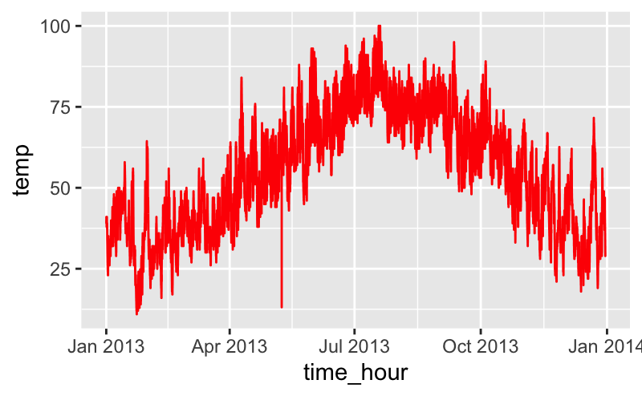

```r
flights_weather <- nycflights13::weather %>%
  select(temp, humid, precip, time_hour)

flights_weather %>%
  ggplot() +
  geom_line(
    aes(y = temp, x = time_hour),
    colour = "red"
  )
```

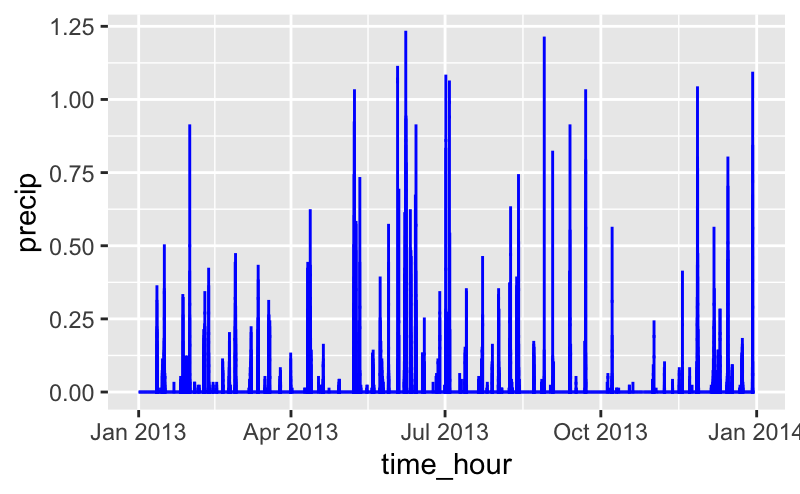

```r
flights_weather %>%
  ggplot() +
  geom_bar(stat = "identity",
    aes(y = precip, x = time_hour),
    colour = "blue"
  )
```

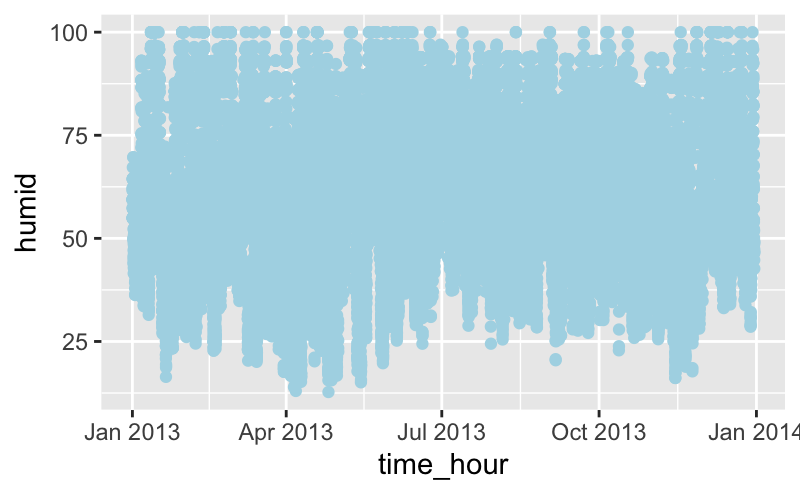

```r
flights_weather %>%
  ggplot() +
  geom_point(stat = "identity",
    aes(y = humid, x = time_hour),
    colour = "light blue"
  )
```

Question 7

Change the weather data into a tsibble.

[output not shown]

[output cut: 990 more lines]

Question 8

Add a year and month column to your weather data, and create a basic line plot which shows the temperature data from each airport over time. Have a think back to what you learned in visualisation week, and think about whether plotting the whole time series in one go is adequate here? Write down your suggestions for what could be done to make a better and more informative plot.

Question 9

Choose an appropriate rolling window and calculate a moving average for your weather temperature data for each airport origin. Create a useful plot which overlays the original time series data and the rolling average data. Make sure the graph is easy for others to understand (Hint: you might want to facet_wrap). Finally, write a summary of why you chose the time window you did, and describe any trends you see.

Question 10

Downsample your data so that you plot daily temperature data for each airport, instead of hourly data.

Question 11

Decompose your daily time series data (the downsampled one) using an appopriate downsampling technique. Justify your choice, and explain what the decomposition shows you. Does it tell you anything about the seasonality that you couldn’t see before?

Question 12

Extract features from your downsampled data. Which airport has the strongest trend?